# League of Legends - Data Modeling

#### Disclaimer

** This notebook should be executed after running Process.Rmd

## 1. Data Preparation

```r
# Load Important Library
library(caret)
library(dplyr)
library(rpart)
# We should load processed_matches.csv that is generated by Process.Rmd.
setwd('/Users/davidleonardi/Projects/KE5107/CA_1/KE5107_LeagueofLegends')
matches <- read.csv("processed_matches.csv", na.strings=c(".", "NA", "", "?"), strip.white=TRUE, encoding="UTF-8")
# Set seed value to make sure our test result is repeatable.
seed_value = 42
set.seed(seed_value)
# Set our target variable as factor.
matches$bResult <- as.factor(make.names(matches$bResult))
```

## 2. Modeling

### 2.1. Before game start

```r
# We use 10-folds cross validation.
train_control <- trainControl(method="cv", number=10, verboseIter=TRUE)
input <- c("rWinEfficiency", "bWinEfficiency",
           "isBluePreferredLineup", "isRedPreferredLineup",
           "isBluePreferredChamps", "isRedPreferredChamps")
target <- "bResult"
data <- na.exclude(matches[, c(input, target)])
# split data to 85% training and 15% testing data
sample_size = floor(0.85 * nrow(data))
training_index = sample(seq_len(nrow(data)), size=sample_size)
training_data = data[training_index,]
testing_data = data[-training_index,]
```

##### 2.1.1. Neural Network

Run grid search for neural network hyperparameters

```r
tunegrid <- expand.grid(.size=c(2, 5, 6, 8, 10, 20), .decay=c(0.01))
```

Train the model.

```r
model <- caret::train(bResult~., data=training_data, trControl=train_control,
               method = "nnet", tuneGrid=tunegrid, metric = "Accuracy", linout = FALSE)
```

Summarize the model.

```r
# summarize results
print(model)
```

```
Neural Network

5999 samples
   6 predictor
   2 classes: 'X0', 'X1'

No pre-processing
Resampling: Cross-Validated (10 fold)
Summary of sample sizes: 5399, 5399, 5399, 5399, 5399, 5399, ...
Resampling results across tuning parameters:

  size  Accuracy   Kappa
   2    0.6969482  0.3845121
   5    0.6974485  0.3854380
   6    0.6971144  0.3847507
   8    0.6927805  0.3758671
  10    0.6939477  0.3778312
  20    0.6971138  0.3845811

Tuning parameter 'decay' was held constant at a value of 0.01
Accuracy was used to select the optimal model using the largest value.
The final values used for the model were size = 5 and decay = 0.01.
```

Run prediction on training data using neural network model.

```r
prediction_train <- predict(model, training_data)
# confusion matrix based on training data
confusionMatrix(prediction_train, training_data$bResult)
```

```
Confusion Matrix and Statistics

          Reference
Prediction   X0   X1
        X0 1685  769
        X1 1056 2489

               Accuracy : 0.6958
                 95% CI : (0.684, 0.7074)
    No Information Rate : 0.5431
    P-Value [Acc > NIR] : < 2.2e-16

                  Kappa : 0.3819
 Mcnemar's Test P-Value : 2.16e-11

            Sensitivity : 0.6147
            Specificity : 0.7640
         Pos Pred Value : 0.6866
         Neg Pred Value : 0.7021
             Prevalence : 0.4569
         Detection Rate : 0.2809
   Detection Prevalence : 0.4091
      Balanced Accuracy : 0.6894

       'Positive' Class : X0
```

Then run prediction on testing data.

```r
# run prediction on testing data
prediction_test <- predict(model, testing_data)
# confusion matrix based on testing data
confusionMatrix(prediction_test, testing_data$bResult)
```

```
Confusion Matrix and Statistics

          Reference
Prediction  X0  X1
        X0 304 152
        X1 168 435

               Accuracy : 0.6978
                 95% CI : (0.6692, 0.7254)
    No Information Rate : 0.5543
    P-Value [Acc > NIR] : <2e-16

                  Kappa : 0.3864
 Mcnemar's Test P-Value : 0.4017

            Sensitivity : 0.6441
            Specificity : 0.7411
         Pos Pred Value : 0.6667
         Neg Pred Value : 0.7214
             Prevalence : 0.4457
         Detection Rate : 0.2871
   Detection Prevalence : 0.4306
      Balanced Accuracy : 0.6926

       'Positive' Class : X0
```

##### 2.1.2. Decision Tree

Run grid search for decision tree hyperparameters.

```r
tunegrid <- expand.grid(.cp = c(0.01, 0.05))
model_control <- rpart.control(minsplit = 20, minbucket = 7, maxdepth = 3)
```

Train the model.

```r
model <- caret::train(bResult~., data=training_data, method = "rpart", tuneGrid = tunegrid,
                      trControl=train_control, control = model_control, metric = "Accuracy")
```

Summarize the model.

```r
# summarize results
print(model)
```

```
CART

5999 samples
   6 predictor
   2 classes: 'X0', 'X1'

No pre-processing
Resampling: Cross-Validated (10 fold)
Summary of sample sizes: 5398, 5399, 5400, 5399, 5399, 5399, ...
Resampling results across tuning parameters:

  cp    Accuracy   Kappa
  0.01  0.6409453  0.2657502
  0.05  0.6126011  0.2184560

Accuracy was used to select the optimal model using the largest value.
The final value used for the model was cp = 0.01.
```

```r
prediction_train <- predict(model, training_data)
# confusion matrix based on training data
confusionMatrix(prediction_train, training_data$bResult)
```

```
Confusion Matrix and Statistics

          Reference
Prediction   X0   X1
        X0 1555  847
        X1 1186 2411

               Accuracy : 0.6611
                 95% CI : (0.649, 0.6731)
    No Information Rate : 0.5431
    P-Value [Acc > NIR] : < 2.2e-16

                  Kappa : 0.3104
 Mcnemar's Test P-Value : 6.564e-14

            Sensitivity : 0.5673
            Specificity : 0.7400
         Pos Pred Value : 0.6474
         Neg Pred Value : 0.6703
             Prevalence : 0.4569
         Detection Rate : 0.2592
   Detection Prevalence : 0.4004
      Balanced Accuracy : 0.6537

       'Positive' Class : X0
```

Then run prediction on testing data.

```r
# run prediction on testing data
prediction_test <- predict(model, testing_data)
# confusion matrix based on testing data
confusionMatrix(prediction_test, testing_data$bResult)
```

```
Confusion Matrix and Statistics

          Reference
Prediction  X0  X1
        X0 260 155
        X1 212 432

               Accuracy : 0.6534
                 95% CI : (0.6239, 0.6821)
    No Information Rate : 0.5543
    P-Value [Acc > NIR] : 3.309e-11

                  Kappa : 0.2902
 Mcnemar's Test P-Value : 0.003465

            Sensitivity : 0.5508
            Specificity : 0.7359
         Pos Pred Value : 0.6265
         Neg Pred Value : 0.6708
             Prevalence : 0.4457
         Detection Rate : 0.2455
   Detection Prevalence : 0.3919
      Balanced Accuracy : 0.6434

       'Positive' Class : X0
```

##### 2.1.3. Random Forest

Train the model.

```r
tunegrid <- expand.grid(.mtry=c(2:6))
modellist <- list()
for (ntree in c(250, 500, 1000, 1500, 2000)) {
  model <- train(bResult~.,  data=training_data,  tuneGrid=tunegrid, ntree=ntree, trControl=train_control,
               metric="Accuracy", method = "rf")
    key <- toString(ntree)
    modellist[[key]] <- model
}
```

Compare results.

```r
models <- resamples(modellist)
summary(models)
```

```
Call:
summary.resamples(object = models)

Models: 250, 500, 1000, 1500, 2000
Number of resamples: 10

Accuracy
          Min.   1st Qu.    Median      Mean   3rd Qu.      Max. NA's
250  0.6633333 0.6754264 0.6872357 0.6872756 0.7012500 0.7133333    0
500  0.6622296 0.6769616 0.6875000 0.6872828 0.6966667 0.7083333    0
1000 0.6550000 0.6791806 0.6875000 0.6886122 0.7011248 0.7150000    0
1500 0.6560935 0.6729222 0.6866667 0.6861047 0.6978765 0.7116667    0
2000 0.6533333 0.6750000 0.6847426 0.6861120 0.6965401 0.7154742    0

Kappa
          Min.   1st Qu.    Median      Mean   3rd Qu.      Max. NA's
250  0.3195904 0.3394202 0.3629299 0.3632468 0.3879874 0.4229995    0
500  0.3131119 0.3413838 0.3616072 0.3625080 0.3823551 0.4072485    0
1000 0.2947189 0.3445405 0.3623604 0.3650694 0.3906512 0.4218155    0
1500 0.3023700 0.3304263 0.3628394 0.3602974 0.3836377 0.4122976    0
2000 0.2911024 0.3405698 0.3570416 0.3602441 0.3822219 0.4163624    0
```

Plot the models.

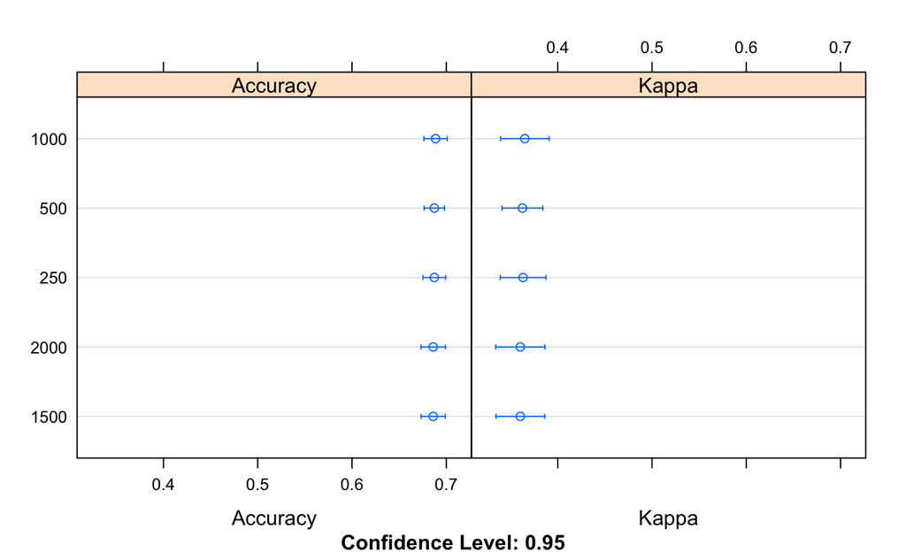

```r
dotplot(models)
```

Pick the best model.

```r
model <- modellist[['1000']]
print(model)
```

```
Random Forest

5999 samples
   6 predictor
   2 classes: 'X0', 'X1'

No pre-processing
Resampling: Cross-Validated (10 fold)
Summary of sample sizes: 5398, 5399, 5400, 5399, 5400, 5399, ...
Resampling results across tuning parameters:

  mtry  Accuracy   Kappa
  2     0.6886122  0.3650694
  3     0.6816089  0.3525500
  4     0.6539383  0.2999127
  5     0.6412719  0.2752780
  6     0.6389380  0.2707825

Accuracy was used to select the optimal model using the largest value.
The final value used for the model was mtry = 2.
```

```r
prediction_train <- predict(model, training_data)
# confusion matrix based on training data
confusionMatrix(prediction_train, training_data$bResult)
```

```
Confusion Matrix and Statistics

          Reference
Prediction   X0   X1
        X0 1711  657
        X1 1021 2610

               Accuracy : 0.7203
                 95% CI : (0.7087, 0.7316)
    No Information Rate : 0.5446
    P-Value [Acc > NIR] : < 2.2e-16

                  Kappa : 0.4299
 Mcnemar's Test P-Value : < 2.2e-16

            Sensitivity : 0.6263
            Specificity : 0.7989
         Pos Pred Value : 0.7226
         Neg Pred Value : 0.7188
             Prevalence : 0.4554
         Detection Rate : 0.2852
   Detection Prevalence : 0.3947
      Balanced Accuracy : 0.7126

       'Positive' Class : X0
```

Then run prediction on testing data.

```r
# run prediction on testing data
prediction_test <- predict(model, testing_data)
# confusion matrix based on testing data
confusionMatrix(prediction_test, testing_data$bResult)
```

```
Confusion Matrix and Statistics

          Reference
Prediction  X0  X1
        X0 298  98
        X1 183 480

               Accuracy : 0.7347
                 95% CI : (0.707, 0.761)
    No Information Rate : 0.5458
    P-Value [Acc > NIR] : < 2.2e-16

                  Kappa : 0.4568
 Mcnemar's Test P-Value : 5.414e-07

            Sensitivity : 0.6195
            Specificity : 0.8304
         Pos Pred Value : 0.7525
         Neg Pred Value : 0.7240
             Prevalence : 0.4542
         Detection Rate : 0.2814
   Detection Prevalence : 0.3739
      Balanced Accuracy : 0.7250

       'Positive' Class : X0
```

##### 2.1.4. Logistic Regression

Train the model.

```r
model <- train(bResult~., data=training_data, trControl=train_control, method="glm", family="binomial")
```

Summarize the model.

```r
print(model)
```

```
Generalized Linear Model

5999 samples
   6 predictor
   2 classes: 'X0', 'X1'

No pre-processing
Resampling: Cross-Validated (10 fold)
Summary of sample sizes: 5399, 5399, 5398, 5400, 5399, 5400, ...
Resampling results:

  Accuracy   Kappa
  0.6927846  0.3771951
```

```r
prediction_train <- predict(model, training_data)
# confusion matrix based on training data
confusionMatrix(prediction_train, training_data$bResult)
```

```
Confusion Matrix and Statistics

          Reference
Prediction   X0   X1
        X0 1728  837
        X1 1004 2430

               Accuracy : 0.6931
                 95% CI : (0.6813, 0.7048)
    No Information Rate : 0.5446
    P-Value [Acc > NIR] : < 2.2e-16

                  Kappa : 0.3782
 Mcnemar's Test P-Value : 0.0001094

            Sensitivity : 0.6325
            Specificity : 0.7438
         Pos Pred Value : 0.6737
         Neg Pred Value : 0.7076
             Prevalence : 0.4554
         Detection Rate : 0.2880
   Detection Prevalence : 0.4276
      Balanced Accuracy : 0.6882

       'Positive' Class : X0
```

Then run prediction on testing data.

```r
# run prediction on testing data
prediction_test <- predict(model, testing_data)
# confusion matrix based on testing data
confusionMatrix(prediction_test, testing_data$bResult)
```

```
Confusion Matrix and Statistics

          Reference
Prediction  X0  X1
        X0 298 123
        X1 183 455

               Accuracy : 0.711
                 95% CI : (0.6827, 0.7382)
    No Information Rate : 0.5458
    P-Value [Acc > NIR] : < 2.2e-16

                  Kappa : 0.411
 Mcnemar's Test P-Value : 0.0007441

            Sensitivity : 0.6195
            Specificity : 0.7872
         Pos Pred Value : 0.7078
         Neg Pred Value : 0.7132
             Prevalence : 0.4542
         Detection Rate : 0.2814
   Detection Prevalence : 0.3975
      Balanced Accuracy : 0.7034

       'Positive' Class : X0
```

##### 2.1.5. Support Vector Machine

```r
tunegrid <- expand.grid(sigma = c(0.005, 0.01, 0.05, 0.1), C = c(0.1, 0.2, 0.5, 1))
model <- train(bResult~.,  data=training_data,  trControl=train_control, method="svmRadial",
               preProc=c("center", "scale"), metric="Accuracy", tuneGrid=tunegrid)
```

Summarize the model.

```r
# summarize results
print(model)
```

```
Support Vector Machines with Radial Basis Function Kernel

5999 samples
   6 predictor
   2 classes: 'X0', 'X1'

Pre-processing: centered (6), scaled (6)
Resampling: Cross-Validated (10 fold)
Summary of sample sizes: 5398, 5400, 5399, 5399, 5398, 5399, ...
Resampling results across tuning parameters:

  sigma  C    Accuracy   Kappa
  0.005  0.1  0.6914521  0.3657694
  0.005  0.2  0.6929543  0.3735881
  0.005  0.5  0.6954524  0.3811639
  0.005  1.0  0.6952851  0.3809896
  0.010  0.1  0.6932871  0.3741833
  0.010  0.2  0.6949521  0.3795081
  0.010  0.5  0.6957840  0.3817925
  0.010  1.0  0.6941182  0.3779951
  0.050  0.1  0.6931176  0.3751563
  0.050  0.2  0.6924504  0.3733016
  0.050  0.5  0.6912840  0.3700367
  0.050  1.0  0.6902860  0.3670041
  0.100  0.1  0.6931173  0.3747984
  0.100  0.2  0.6909512  0.3696610
  0.100  0.5  0.6882846  0.3641439
  0.100  1.0  0.6901154  0.3680460

Accuracy was used to select the optimal model using the largest value.
The final values used for the model were sigma = 0.01 and C = 0.5.
```

```r
# run prediction on training data
prediction_train <- predict(model, training_data)
# confusion matrix based on training data
confusionMatrix(prediction_train, training_data$bResult)
```

```
Confusion Matrix and Statistics

          Reference
Prediction   X0   X1
        X0 1681  767
        X1 1051 2500

               Accuracy : 0.6969
                 95% CI : (0.6851, 0.7086)
    No Information Rate : 0.5446
    P-Value [Acc > NIR] : < 2.2e-16

                  Kappa : 0.3838
 Mcnemar's Test P-Value : 3.195e-11

            Sensitivity : 0.6153
            Specificity : 0.7652
         Pos Pred Value : 0.6867
         Neg Pred Value : 0.7040
             Prevalence : 0.4554
         Detection Rate : 0.2802
   Detection Prevalence : 0.4081
      Balanced Accuracy : 0.6903

       'Positive' Class : X0
```

Then run prediction on testing data.

```r
# run prediction on testing data
prediction_test <- predict(model, testing_data)
# confusion matrix based on testing data
confusionMatrix(prediction_test, testing_data$bResult)
```

```
Confusion Matrix and Statistics

          Reference
Prediction  X0  X1
        X0 291 113
        X1 190 465

               Accuracy : 0.7139
                 95% CI : (0.6856, 0.7409)
    No Information Rate : 0.5458
    P-Value [Acc > NIR] : < 2.2e-16

                  Kappa : 0.4151
 Mcnemar's Test P-Value : 1.265e-05

            Sensitivity : 0.6050
            Specificity : 0.8045
         Pos Pred Value : 0.7203
         Neg Pred Value : 0.7099
             Prevalence : 0.4542
         Detection Rate : 0.2748
   Detection Prevalence : 0.3815
      Balanced Accuracy : 0.7047

       'Positive' Class : X0
```

##### 2.1.6. Extreme Gradient Boosting

```r
tunegrid <- expand.grid(
  "eta" = c(0.1, 0.2, 0.3, 0.4, 0.5),
  "max_depth" = c(4, 5, 6),
  "gamma" = c(0),
  "subsample" = c(0.5, 0.9),
  "colsample_bytree" = c(0.8),
  "nrounds" = c(25, 50, 75, 100),
  "min_child_weight" = c(0, 1)
)
model <- train(bResult~., data=training_data, trControl=train_control, method = "xgbTree",
               metric = "Accuracy", tuneGrid=tunegrid)
```

Summarize the model.

```r
# summarize results
print(model)
```

```
eXtreme Gradient Boosting

5999 samples
   6 predictor
   2 classes: 'X0', 'X1'

No pre-processing
Resampling: Cross-Validated (10 fold)
Summary of sample sizes: 5400, 5399, 5398, 5399, 5398, 5400, ...
Resampling results across tuning parameters:

  eta  max_depth  min_child_weight  subsample  nrounds  Accuracy   Kappa
  0.1  4          0                 0.5         25      0.6804557  0.3507529
  0.1  4          0                 0.5         50      0.6791185  0.3483362
  0.1  4          0                 0.5         75      0.6762851  0.3428222
  0.1  4          0                 0.5        100      0.6729515  0.3357956
  0.1  4          0                 0.9         25      0.6739473  0.3368120
  0.1  4          0                 0.9         50      0.6756157  0.3410368
  0.1  4          0                 0.9         75      0.6771157  0.3442979
  0.1  4          0                 0.9        100      0.6777823  0.3456839
  0.1  4          1                 0.5         25      0.6811196  0.3516436
  0.1  4          1                 0.5         50      0.6782801  0.3464723
  0.1  4          1                 0.5         75      0.6796143  0.3488437
  0.1  4          1                 0.5        100      0.6756098  0.3412126
  0.1  4          1                 0.9         25      0.6736134  0.3365514
  0.1  4          1                 0.9         50      0.6744484  0.3388360
  0.1  4          1                 0.9         75      0.6719468  0.3339321
  0.1  4          1                 0.9        100      0.6721137  0.3339691
  0.1  5          0                 0.5         25      0.6786179  0.3467669
  0.1  5          0                 0.5         50      0.6739487  0.3380232
  0.1  5          0                 0.5         75      0.6746137  0.3395776
  0.1  5          0                 0.5        100      0.6704462  0.3309005
  0.1  5          0                 0.9         25      0.6739512  0.3380172
  0.1  5          0                 0.9         50      0.6756182  0.3412572
  0.1  5          0                 0.9         75      0.6732829  0.3360868
  0.1  5          0                 0.9        100      0.6707829  0.3311653
  0.1  5          1                 0.5         25      0.6789537  0.3478414
  0.1  5          1                 0.5         50      0.6756151  0.3405568
  0.1  5          1                 0.5         75      0.6739504  0.3377815
  0.1  5          1                 0.5        100      0.6727820  0.3351416
```

[output cut: 107 more lines]

```
  0.3  6          0                 0.9        100      0.6459381  0.2836797
  0.3  6          1                 0.5         25      0.6661168  0.3229804
  0.3  6          1                 0.5         50      0.6541073  0.2985322
  0.3  6          1                 0.5         75      0.6476034  0.2868183
  0.3  6          1                 0.5        100      0.6454317  0.2826202
  0.3  6          1                 0.9         25      0.6679398  0.3256725
  0.3  6          1                 0.9         50      0.6634418  0.3173186
 [ reached getOption("max.print") -- omitted 98 rows ]

Tuning parameter 'gamma' was held constant at a value of 0
Tuning parameter 'colsample_bytree' was
 held constant at a value of 0.8
Accuracy was used to select the optimal model using the largest value.
The final values used for the model were nrounds = 25, max_depth = 5, eta = 0.2, gamma =
 0, colsample_bytree = 0.8, min_child_weight = 1 and subsample = 0.9.
```

```r
# run prediction on training data
prediction_train <- predict(model, training_data)
# confusion matrix based on training data
confusionMatrix(prediction_train, training_data$bResult)
```

```
Confusion Matrix and Statistics

          Reference
Prediction   X0   X1
        X0 1719  731
        X1 1013 2536

               Accuracy : 0.7093
                 95% CI : (0.6976, 0.7208)
    No Information Rate : 0.5446
    P-Value [Acc > NIR] : < 2.2e-16

                  Kappa : 0.4089
 Mcnemar's Test P-Value : 1.712e-11

            Sensitivity : 0.6292
            Specificity : 0.7762
         Pos Pred Value : 0.7016
         Neg Pred Value : 0.7146
             Prevalence : 0.4554
         Detection Rate : 0.2865
   Detection Prevalence : 0.4084
      Balanced Accuracy : 0.7027

       'Positive' Class : X0
```

Then run prediction on testing data.

```r
# run prediction on testing data
prediction_test <- predict(model, testing_data)
# confusion matrix based on testing data
confusionMatrix(prediction_test, testing_data$bResult)
```

```
Confusion Matrix and Statistics

          Reference
Prediction  X0  X1
        X0 288 129
        X1 193 449

               Accuracy : 0.6959
                 95% CI : (0.6672, 0.7235)
    No Information Rate : 0.5458
    P-Value [Acc > NIR] : < 2.2e-16

                  Kappa : 0.3798
 Mcnemar's Test P-Value : 0.0004467

            Sensitivity : 0.5988
            Specificity : 0.7768
         Pos Pred Value : 0.6906
         Neg Pred Value : 0.6994
             Prevalence : 0.4542
         Detection Rate : 0.2720
   Detection Prevalence : 0.3938
      Balanced Accuracy : 0.6878

       'Positive' Class : X0
```

### 2.2. Five (5) Minutes after the game start

```r
# We use 10-folds cross validation.
train_control <- trainControl(method="cv", number=10, verboseIter=TRUE)
input <- c("rWinEfficiency", "bWinEfficiency",
           "bTowers5Mins", "rTowers5Mins",
           "bDragons5Mins", "rDragons5Mins",
           "bKills5Mins", "rKills5Mins",
           "goldblue5Mins", "goldred5Mins",
           "isBluePreferredLineup", "isRedPreferredLineup",
           "isBluePreferredChamps", "isRedPreferredChamps")
target <- "bResult"
data <- matches[, c(input, target)]
# split data to 85% training and 15% testing data
sample_size = floor(0.85 * nrow(data))
training_index = sample(seq_len(nrow(data)), size=sample_size)
training_data = data[training_index,]
testing_data = data[-training_index,]
```

##### 2.2.1. Neural Network

Run grid search for neural network hyperparameters

```r
tunegrid <- expand.grid(.size=c(2, 5, 6, 8, 10), .decay=c(0.01))
```

Train the model.

```r
model <- caret::train(bResult~., data=training_data, trControl=train_control,
               method = "nnet", tuneGrid=tunegrid, metric = "Accuracy", linout = FALSE)
```

Summarize the model.

```r
# summarize results
print(model)
```

```
Neural Network

5999 samples
  14 predictor
   2 classes: 'X0', 'X1'

No pre-processing
Resampling: Cross-Validated (10 fold)
Summary of sample sizes: 5399, 5399, 5399, 5400, 5400, 5399, ...
Resampling results across tuning parameters:

  size  Accuracy   Kappa
   2    0.6137786  0.1784912
   5    0.6889706  0.3592975
   6    0.6656226  0.3192874
   8    0.6618079  0.2935298
  10    0.6871171  0.3661901

Tuning parameter 'decay' was held constant at a value of 0.01
Accuracy was used to select the optimal model using the largest value.
The final values used for the model were size = 5 and decay = 0.01.
```

Run prediction on training data using neural network model.

```r
# run prediction on training data
prediction_train <- predict(model, training_data)
# confusion matrix based on training data
confusionMatrix(prediction_train, training_data$bResult)
```

```
Confusion Matrix and Statistics

          Reference
Prediction   X0   X1
        X0 1729  752
        X1  986 2532

               Accuracy : 0.7103
                 95% CI : (0.6986, 0.7217)
    No Information Rate : 0.5474
    P-Value [Acc > NIR] : < 2.2e-16

                  Kappa : 0.4109
 Mcnemar's Test P-Value : 2.284e-08

            Sensitivity : 0.6368
            Specificity : 0.7710
         Pos Pred Value : 0.6969
         Neg Pred Value : 0.7197
             Prevalence : 0.4526
         Detection Rate : 0.2882
   Detection Prevalence : 0.4136
      Balanced Accuracy : 0.7039

       'Positive' Class : X0
```

Then run prediction on testing data.

```r
# run prediction on testing data
prediction_test <- predict(model, testing_data)
# confusion matrix based on testing data
confusionMatrix(prediction_test, testing_data$bResult)
```

```
Confusion Matrix and Statistics

          Reference
Prediction  X0  X1
        X0 316 132
        X1 182 429

               Accuracy : 0.7035
                 95% CI : (0.675, 0.7309)
    No Information Rate : 0.5297
    P-Value [Acc > NIR] : < 2.2e-16

                  Kappa : 0.4015
 Mcnemar's Test P-Value : 0.005688

            Sensitivity : 0.6345
            Specificity : 0.7647
         Pos Pred Value : 0.7054
         Neg Pred Value : 0.7021
             Prevalence : 0.4703
         Detection Rate : 0.2984
   Detection Prevalence : 0.4230
      Balanced Accuracy : 0.6996

       'Positive' Class : X0
```

##### 2.2.2. Decision Tree

Run grid search for decision tree hyperparameters.

```r
tunegrid <- expand.grid(.cp = c(0.01, 0.05))
model_control <- rpart.control(minsplit = 20, minbucket = 7, maxdepth = 3)
```

Train the model.

```r
model <- caret::train(bResult~., data=training_data, method = "rpart", tuneGrid = tunegrid,
                      trControl=train_control, control = model_control, metric = "Accuracy")
```

Summarize the model.

```r
# summarize results
print(model)
```

```
CART

5999 samples
  14 predictor
   2 classes: 'X0', 'X1'

No pre-processing
Resampling: Cross-Validated (10 fold)
Summary of sample sizes: 5399, 5398, 5399, 5399, 5400, 5398, ...
Resampling results across tuning parameters:

  cp    Accuracy   Kappa
  0.01  0.6561073  0.2994058
  0.05  0.6219342  0.2322499

Accuracy was used to select the optimal model using the largest value.
The final value used for the model was cp = 0.01.
```

```r
prediction_train <- predict(model, training_data)
# confusion matrix based on training data
confusionMatrix(prediction_train, training_data$bResult)
```

```
Confusion Matrix and Statistics

          Reference
Prediction   X0   X1
        X0 1708 1007
        X1 1007 2277

               Accuracy : 0.6643
                 95% CI : (0.6522, 0.6762)
    No Information Rate : 0.5474
    P-Value [Acc > NIR] : <2e-16

                  Kappa : 0.3225
 Mcnemar's Test P-Value : 1

            Sensitivity : 0.6291
            Specificity : 0.6934
         Pos Pred Value : 0.6291
         Neg Pred Value : 0.6934
             Prevalence : 0.4526
         Detection Rate : 0.2847
   Detection Prevalence : 0.4526
      Balanced Accuracy : 0.6612

       'Positive' Class : X0
```

Then run prediction on testing data.

```r
# run prediction on testing data
prediction_test <- predict(model, testing_data)
# confusion matrix based on testing data
confusionMatrix(prediction_test, testing_data$bResult)
```

```
Confusion Matrix and Statistics

          Reference
Prediction  X0  X1
        X0 297 177
        X1 201 384

               Accuracy : 0.6431
                 95% CI : (0.6134, 0.672)
    No Information Rate : 0.5297
    P-Value [Acc > NIR] : 5.751e-14

                  Kappa : 0.2816
 Mcnemar's Test P-Value : 0.2368

            Sensitivity : 0.5964
            Specificity : 0.6845
         Pos Pred Value : 0.6266
         Neg Pred Value : 0.6564
             Prevalence : 0.4703
         Detection Rate : 0.2805
   Detection Prevalence : 0.4476
      Balanced Accuracy : 0.6404

       'Positive' Class : X0
```

##### 2.2.3. Random Forest

Train the model.

```r
tunegrid <- expand.grid(.mtry=c(2:4))
modellist <- list()
for (ntree in c(250, 500, 1000)) {
  model <- train(bResult~.,  data=training_data,  tuneGrid=tunegrid, ntree=ntree, trControl=train_control,
               metric="Accuracy", method = "rf")
    key <- toString(ntree)
    modellist[[key]] <- model
}
```

Compare results.

```r
models <- resamples(modellist)
summary(models)
```

```
Call:
summary.resamples(object = models)

Models: 250, 500, 1000
Number of resamples: 10

Accuracy
          Min.   1st Qu.    Median      Mean   3rd Qu.      Max. NA's
250  0.6761269 0.6894574 0.6997496 0.6999339 0.7107765 0.7221298    0
500  0.6527546 0.6745764 0.6933353 0.6927757 0.7083333 0.7383333    0
1000 0.6550000 0.6896098 0.6985857 0.6971179 0.7050494 0.7262104    0

Kappa
         Min.   1st Qu.    Median      Mean   3rd Qu.      Max. NA's
250  0.337412 0.3652826 0.3845421 0.3855088 0.4074616 0.4325284    0
500  0.286815 0.3326142 0.3726652 0.3702894 0.4041408 0.4624638    0
1000 0.293065 0.3644475 0.3828431 0.3797805 0.3946714 0.4387797    0
```

Plot the models.

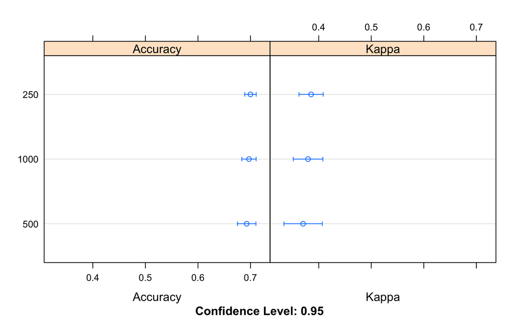

```r
dotplot(models)
```

Pick the best model.

```r
model <- modellist[['250']]
print(model)
```

```
Random Forest

5999 samples
  14 predictor
   2 classes: 'X0', 'X1'

No pre-processing
Resampling: Cross-Validated (10 fold)
Summary of sample sizes: 5398, 5399, 5398, 5400, 5399, 5398, ...
Resampling results across tuning parameters:

  mtry  Accuracy   Kappa
  2     0.6999339  0.3855088
  3     0.6977694  0.3837087
  4     0.6879361  0.3646583

Accuracy was used to select the optimal model using the largest value.
The final value used for the model was mtry = 2.
```

```r
prediction_train <- predict(model, training_data)
# confusion matrix based on training data
confusionMatrix(prediction_train, training_data$bResult)
```

```
Confusion Matrix and Statistics

          Reference
Prediction   X0   X1
        X0 1885  417
        X1  830 2867

               Accuracy : 0.7921
                 95% CI : (0.7816, 0.8023)
    No Information Rate : 0.5474
    P-Value [Acc > NIR] : < 2.2e-16

                  Kappa : 0.5749
 Mcnemar's Test P-Value : < 2.2e-16

            Sensitivity : 0.6943
            Specificity : 0.8730
         Pos Pred Value : 0.8189
         Neg Pred Value : 0.7755
             Prevalence : 0.4526
         Detection Rate : 0.3142
   Detection Prevalence : 0.3837
      Balanced Accuracy : 0.7837

       'Positive' Class : X0
```

Then run prediction on testing data.

```r
# run prediction on testing data
prediction_test <- predict(model, testing_data)
# confusion matrix based on testing data
confusionMatrix(prediction_test, testing_data$bResult)
```

```
Confusion Matrix and Statistics

          Reference
Prediction  X0  X1
        X0 293 115
        X1 205 446

               Accuracy : 0.6978
                 95% CI : (0.6692, 0.7254)
    No Information Rate : 0.5297
    P-Value [Acc > NIR] : < 2.2e-16

                  Kappa : 0.3873
 Mcnemar's Test P-Value : 6.516e-07

            Sensitivity : 0.5884
            Specificity : 0.7950
         Pos Pred Value : 0.7181
         Neg Pred Value : 0.6851
             Prevalence : 0.4703
         Detection Rate : 0.2767
   Detection Prevalence : 0.3853
      Balanced Accuracy : 0.6917

       'Positive' Class : X0
```

##### 2.2.4. Logistic Regression

Train the model.

```r
model <- train(bResult~., data=training_data, trControl=train_control, method="glm", family="binomial")
```

Summarize the model.

```r
# summarize results
print(model)
```

```
Generalized Linear Model

5999 samples
  14 predictor
   2 classes: 'X0', 'X1'

No pre-processing
Resampling: Cross-Validated (10 fold)
Summary of sample sizes: 5399, 5400, 5398, 5400, 5399, 5398, ...
Resampling results:

  Accuracy   Kappa
  0.7074439  0.4053478
```

```r
prediction_train <- predict(model, training_data)
# confusion matrix based on training data
confusionMatrix(prediction_train, training_data$bResult)
```

```
Confusion Matrix and Statistics

          Reference
Prediction   X0   X1
        X0 1737  760
        X1  978 2524

               Accuracy : 0.7103
                 95% CI : (0.6986, 0.7217)
    No Information Rate : 0.5474
    P-Value [Acc > NIR] : < 2.2e-16

                  Kappa : 0.4112
 Mcnemar's Test P-Value : 1.938e-07

            Sensitivity : 0.6398
            Specificity : 0.7686
         Pos Pred Value : 0.6956
         Neg Pred Value : 0.7207
             Prevalence : 0.4526
         Detection Rate : 0.2895
   Detection Prevalence : 0.4162
      Balanced Accuracy : 0.7042

       'Positive' Class : X0
```

Then run prediction on testing data.

```r
# run prediction on testing data
prediction_test <- predict(model, testing_data)
# confusion matrix based on testing data
confusionMatrix(prediction_test, testing_data$bResult)
```

```
Confusion Matrix and Statistics

          Reference
Prediction  X0  X1
        X0 318 131
        X1 180 430

               Accuracy : 0.7063
                 95% CI : (0.6779, 0.7336)
    No Information Rate : 0.5297
    P-Value [Acc > NIR] : < 2.2e-16

                  Kappa : 0.4073
 Mcnemar's Test P-Value : 0.006492

            Sensitivity : 0.6386
            Specificity : 0.7665
         Pos Pred Value : 0.7082
         Neg Pred Value : 0.7049
             Prevalence : 0.4703
         Detection Rate : 0.3003
   Detection Prevalence : 0.4240
      Balanced Accuracy : 0.7025

       'Positive' Class : X0
```

##### 2.2.5. Support Vector Machine

```r
tunegrid <- expand.grid(sigma = c(0.005, 0.01, 0.05, 0.1), C = c(0.1, 0.2, 0.5, 1))
model <- train(bResult~.,  data=training_data,  trControl=train_control, method="svmRadial",
               preProc=c("center", "scale"), metric="Accuracy", tuneGrid=tunegrid)
```

Summarize the model.

```r
# summarize results
print(model)
```

```
Support Vector Machines with Radial Basis Function Kernel

5999 samples
  14 predictor
   2 classes: 'X0', 'X1'

Pre-processing: centered (14), scaled (14)
Resampling: Cross-Validated (10 fold)
Summary of sample sizes: 5400, 5399, 5400, 5398, 5399, 5399, ...
Resampling results across tuning parameters:

  sigma  C    Accuracy   Kappa
  0.005  0.1  0.7021185  0.3866712
  0.005  0.2  0.7097902  0.4057200
  0.005  0.5  0.7109596  0.4103284
  0.005  1.0  0.7091246  0.4070161
  0.010  0.1  0.7089577  0.4035651
  0.010  0.2  0.7102896  0.4084432
  0.010  0.5  0.7092916  0.4072052
  0.010  1.0  0.7082896  0.4050336
  0.050  0.1  0.7054543  0.3982811
  0.050  0.2  0.7039552  0.3951316
  0.050  0.5  0.7044552  0.3955247
  0.050  1.0  0.7016201  0.3897318
  0.100  0.1  0.7006229  0.3871038
  0.100  0.2  0.7021221  0.3907270
  0.100  0.5  0.7016204  0.3898996
  0.100  1.0  0.6996218  0.3868542

Accuracy was used to select the optimal model using the largest value.
The final values used for the model were sigma = 0.005 and C = 0.5.
```

```r
# run prediction on training data
prediction_train <- predict(model, training_data)
# confusion matrix based on training data
confusionMatrix(prediction_train, training_data$bResult)
```

```
Confusion Matrix and Statistics

          Reference
Prediction   X0   X1
        X0 1686  696
        X1 1029 2588

               Accuracy : 0.7125
                 95% CI : (0.7008, 0.7239)
    No Information Rate : 0.5474
    P-Value [Acc > NIR] : < 2.2e-16

                  Kappa : 0.4135
 Mcnemar's Test P-Value : 1.31e-15

            Sensitivity : 0.6210
            Specificity : 0.7881
         Pos Pred Value : 0.7078
         Neg Pred Value : 0.7155
             Prevalence : 0.4526
         Detection Rate : 0.2810
   Detection Prevalence : 0.3971
      Balanced Accuracy : 0.7045

       'Positive' Class : X0
```

Then run prediction on testing data.

```r
# run prediction on testing data
prediction_test <- predict(model, testing_data)
# confusion matrix based on testing data
confusionMatrix(prediction_test, testing_data$bResult)
```

```
Confusion Matrix and Statistics

          Reference
Prediction  X0  X1
        X0 304 122
        X1 194 439

               Accuracy : 0.7016
                 95% CI : (0.673, 0.729)
    No Information Rate : 0.5297
    P-Value [Acc > NIR] : < 2.2e-16

                  Kappa : 0.3962
 Mcnemar's Test P-Value : 6.495e-05

            Sensitivity : 0.6104
            Specificity : 0.7825
         Pos Pred Value : 0.7136
         Neg Pred Value : 0.6935
             Prevalence : 0.4703
         Detection Rate : 0.2871
   Detection Prevalence : 0.4023
      Balanced Accuracy : 0.6965

       'Positive' Class : X0
```

##### 2.2.6. Extreme Gradient Boosting

```r
tunegrid <- expand.grid(
  "eta" = c(0.2, 0.3, 0.4),
  "max_depth" = c(4, 5, 6),
  "gamma" = c(0),
  "subsample" = c(0.5, 0.9),
  "colsample_bytree" = c(0.8),
  "nrounds" = c(25, 50, 75, 100),
  "min_child_weight" = c(0, 1)
)
model <- train(bResult~., data=training_data, trControl=train_control, method = "xgbTree",
               metric = "Accuracy", tuneGrid=tunegrid)
```

```
Fitting nrounds = 25, max_depth = 5, eta = 0.2, gamma = 0, colsample_bytree = 0.8, min_child_weight = 0, subsample = 0.5 on full training set
```

Summarize the model.

```r
# summarize results
print(model)
```

```
eXtreme Gradient Boosting

5999 samples
  14 predictor
   2 classes: 'X0', 'X1'

No pre-processing
Resampling: Cross-Validated (10 fold)
Summary of sample sizes: 5398, 5398, 5399, 5400, 5400, 5398, ...
Resampling results across tuning parameters:

  eta  max_depth  min_child_weight  subsample  nrounds  Accuracy   Kappa
  0.2  4          0                 0.5         25      0.6892886  0.3667083
  0.2  4          0                 0.5         50      0.6882838  0.3650031
  0.2  4          0                 0.5         75      0.6854549  0.3589901
  0.2  4          0                 0.5        100      0.6761224  0.3405492
  0.2  4          0                 0.9         25      0.6907836  0.3696259
  0.2  4          0                 0.9         50      0.6904541  0.3698548
  0.2  4          0                 0.9         75      0.6841152  0.3574578
  0.2  4          0                 0.9        100      0.6851180  0.3594358
  0.2  4          1                 0.5         25      0.6901230  0.3688082
  0.2  4          1                 0.5         50      0.6869569  0.3619763
  0.2  4          1                 0.5         75      0.6787866  0.3463151
  0.2  4          1                 0.5        100      0.6782838  0.3451826
  0.2  4          1                 0.9         25      0.6876202  0.3634030
  0.2  4          1                 0.9         50      0.6879544  0.3642007
  0.2  4          1                 0.9         75      0.6856186  0.3590773
  0.2  4          1                 0.9        100      0.6804469  0.3491407
  0.2  5          0                 0.5         25      0.6929547  0.3747627
  0.2  5          0                 0.5         50      0.6837883  0.3559268
  0.2  5          0                 0.5         75      0.6756169  0.3396002
  0.2  5          0                 0.5        100      0.6684463  0.3259164
  0.2  5          0                 0.9         25      0.6861166  0.3604667
  0.2  5          0                 0.9         50      0.6866177  0.3613479
  0.2  5          0                 0.9         75      0.6806166  0.3494170
  0.2  5          0                 0.9        100      0.6786069  0.3453551
  0.2  5          1                 0.5         25      0.6794569  0.3465736
  0.2  5          1                 0.5         50      0.6817824  0.3520461
  0.2  5          1                 0.5         75      0.6739455  0.3361548
  0.2  5          1                 0.5        100      0.6727830  0.3347516
```

[output cut: 107 more lines]

```
  0.4  6          0                 0.9        100      0.6574338  0.3049442
  0.4  6          1                 0.5         25      0.6587766  0.3061492
  0.4  6          1                 0.5         50      0.6437746  0.2775275
  0.4  6          1                 0.5         75      0.6412804  0.2728012
  0.4  6          1                 0.5        100      0.6391112  0.2692264
  0.4  6          1                 0.9         25      0.6741099  0.3364485
  0.4  6          1                 0.9         50      0.6652777  0.3200798
 [ reached getOption("max.print") -- omitted 2 rows ]

Tuning parameter 'gamma' was held constant at a value of 0
Tuning parameter 'colsample_bytree' was
 held constant at a value of 0.8
Accuracy was used to select the optimal model using the largest value.
The final values used for the model were nrounds = 25, max_depth = 5, eta = 0.2, gamma =
 0, colsample_bytree = 0.8, min_child_weight = 0 and subsample = 0.5.
```

```r
# run prediction on training data
prediction_train <- predict(model, training_data)
# confusion matrix based on training data
confusionMatrix(prediction_train, training_data$bResult)
```

```
Confusion Matrix and Statistics

          Reference
Prediction   X0   X1
        X0 1777  672
        X1  938 2612

               Accuracy : 0.7316
                 95% CI : (0.7202, 0.7428)
    No Information Rate : 0.5474
    P-Value [Acc > NIR] : < 2.2e-16

                  Kappa : 0.4537
 Mcnemar's Test P-Value : 3.991e-11

            Sensitivity : 0.6545
            Specificity : 0.7954
         Pos Pred Value : 0.7256
         Neg Pred Value : 0.7358
             Prevalence : 0.4526
         Detection Rate : 0.2962
   Detection Prevalence : 0.4082
      Balanced Accuracy : 0.7249

       'Positive' Class : X0
```

Then run prediction on testing data.

```r
# run prediction on testing data
prediction_test <- predict(model, testing_data)
# confusion matrix based on testing data
confusionMatrix(prediction_test, testing_data$bResult)
```

```
Confusion Matrix and Statistics

          Reference
Prediction  X0  X1
        X0 299 144
        X1 199 417

               Accuracy : 0.6761
                 95% CI : (0.647, 0.7042)
    No Information Rate : 0.5297
    P-Value [Acc > NIR] : < 2.2e-16

                  Kappa : 0.3459
 Mcnemar's Test P-Value : 0.003549

            Sensitivity : 0.6004
            Specificity : 0.7433
         Pos Pred Value : 0.6749
         Neg Pred Value : 0.6769
             Prevalence : 0.4703
         Detection Rate : 0.2823
   Detection Prevalence : 0.4183
      Balanced Accuracy : 0.6719

       'Positive' Class : X0
```

### 2.3. Ten (10) Minutes after the game start

```r
# We use 10-folds cross validation.
train_control <- trainControl(method="cv", number=10, verboseIter=TRUE)
input <- c("rWinEfficiency", "bWinEfficiency",
           "bTowers10Mins", "rTowers10Mins",
           "rInhibs10Mins",
           "bDragons10Mins", "rDragons10Mins",
           "bKills10Mins", "rKills10Mins",
           "goldblue10Mins", "goldred10Mins",
           "isBluePreferredLineup", "isRedPreferredLineup",
           "isBluePreferredChamps", "isRedPreferredChamps")
target <- "bResult"
data <- matches[, c(input, target)]
# split data to 85% training and 15% testing data
sample_size = floor(0.85 * nrow(data))
training_index = sample(seq_len(nrow(data)), size=sample_size)
training_data = data[training_index,]
testing_data = data[-training_index,]
```

##### 2.3.1. Neural Network

Run grid search for neural network hyperparameters

```r
tunegrid <- expand.grid(.size=c(2, 5, 6, 8, 10), .decay=c(0.01))
```

Train the model.

```r
model <- caret::train(bResult~., data=training_data, trControl=train_control,
               method = "nnet", tuneGrid=tunegrid, metric = "Accuracy", linout = FALSE)
```

Summarize the model.

```r
# summarize results
print(model)
```

```
Neural Network

5999 samples
  15 predictor
   2 classes: 'X0', 'X1'

No pre-processing
Resampling: Cross-Validated (10 fold)
Summary of sample sizes: 5399, 5400, 5399, 5399, 5399, 5399, ...
Resampling results across tuning parameters:

  size  Accuracy   Kappa
   2    0.6184243  0.1812072
   5    0.6877811  0.3674468
   6    0.6991172  0.3863995
   8    0.7240975  0.4415863
  10    0.7081220  0.4103443

Tuning parameter 'decay' was held constant at a value of 0.01
Accuracy was used to select the optimal model using the largest value.
The final values used for the model were size = 8 and decay = 0.01.
```

Run prediction on training data using neural network model.

```r
# run prediction on training data
prediction_train <- predict(model, training_data)
# confusion matrix based on training data
confusionMatrix(prediction_train, training_data$bResult)
```

```
Confusion Matrix and Statistics

          Reference
Prediction   X0   X1
        X0    0    0
        X1 2722 3277

               Accuracy : 0.5463
                 95% CI : (0.5336, 0.5589)
    No Information Rate : 0.5463
    P-Value [Acc > NIR] : 0.5053

                  Kappa : 0
 Mcnemar's Test P-Value : <2e-16

            Sensitivity : 0.0000
            Specificity : 1.0000
         Pos Pred Value :    NaN
         Neg Pred Value : 0.5463
             Prevalence : 0.4537
         Detection Rate : 0.0000
   Detection Prevalence : 0.0000
      Balanced Accuracy : 0.5000

       'Positive' Class : X0
```

Then run prediction on testing data.

```r
# run prediction on testing data
prediction_test <- predict(model, testing_data)
# confusion matrix based on testing data
confusionMatrix(prediction_test, testing_data$bResult)
```

```
Confusion Matrix and Statistics

          Reference
Prediction  X0  X1
        X0   0   0
        X1 491 568

               Accuracy : 0.5364
                 95% CI : (0.5058, 0.5667)
    No Information Rate : 0.5364
    P-Value [Acc > NIR] : 0.5126

                  Kappa : 0
 Mcnemar's Test P-Value : <2e-16

            Sensitivity : 0.0000
            Specificity : 1.0000
         Pos Pred Value :    NaN
         Neg Pred Value : 0.5364
             Prevalence : 0.4636
         Detection Rate : 0.0000
   Detection Prevalence : 0.0000
      Balanced Accuracy : 0.5000

       'Positive' Class : X0
```

##### 2.3.2. Decision Tree

Run grid search for decision tree hyperparameters.

```r
tunegrid <- expand.grid(.cp = c(0.01, 0.05))
model_control <- rpart.control(minsplit = 20, minbucket = 7, maxdepth = 3)
```

Train the model.

```r
model <- caret::train(bResult~., data=training_data, method = "rpart", tuneGrid = tunegrid,
                      trControl=train_control, control = model_control, metric = "Accuracy")
```

Summarize the model.

```r
# summarize results
print(model)
```

```
CART

5999 samples
  15 predictor
   2 classes: 'X0', 'X1'

No pre-processing
Resampling: Cross-Validated (10 fold)
Summary of sample sizes: 5400, 5399, 5399, 5398, 5399, 5400, ...
Resampling results across tuning parameters:

  cp    Accuracy  Kappa
  0.01  0.65194   0.2872402
  0.05  0.59610   0.1787661

Accuracy was used to select the optimal model using the largest value.
The final value used for the model was cp = 0.01.
```

```r
prediction_train <- predict(model, training_data)
# confusion matrix based on training data
confusionMatrix(prediction_train, training_data$bResult)
```

```
Confusion Matrix and Statistics

          Reference
Prediction   X0   X1
        X0 1709  963
        X1 1013 2314

               Accuracy : 0.6706
                 95% CI : (0.6586, 0.6825)
    No Information Rate : 0.5463
    P-Value [Acc > NIR] : <2e-16

                  Kappa : 0.3345
 Mcnemar's Test P-Value : 0.2703

            Sensitivity : 0.6278
            Specificity : 0.7061
         Pos Pred Value : 0.6396
         Neg Pred Value : 0.6955
             Prevalence : 0.4537
         Detection Rate : 0.2849
   Detection Prevalence : 0.4454
      Balanced Accuracy : 0.6670

       'Positive' Class : X0
```

Then run prediction on testing data.

```r
# run prediction on testing data
prediction_test <- predict(model, testing_data)
# confusion matrix based on testing data
confusionMatrix(prediction_test, testing_data$bResult)
```

```
Confusion Matrix and Statistics

          Reference
Prediction  X0  X1
        X0 312 197
        X1 179 371

               Accuracy : 0.6449
                 95% CI : (0.6153, 0.6738)
    No Information Rate : 0.5364
    P-Value [Acc > NIR] : 5.353e-13

                  Kappa : 0.2879
 Mcnemar's Test P-Value : 0.3806

            Sensitivity : 0.6354
            Specificity : 0.6532
         Pos Pred Value : 0.6130
         Neg Pred Value : 0.6745
             Prevalence : 0.4636
         Detection Rate : 0.2946
   Detection Prevalence : 0.4806
      Balanced Accuracy : 0.6443

       'Positive' Class : X0
```

##### 2.3.3. Random Forest

Train the model.

```r
tunegrid <- expand.grid(.mtry=c(2:4))

modellist <- list()
for (ntree in c(250, 500, 1000)) {
  model <- train(bResult~.,  data=training_data,  tuneGrid=tunegrid, ntree=ntree, trControl=train_control,
               metric="Accuracy", method = "rf")
    key <- toString(ntree)
    modellist[[key]] <- model
}
```

Compare results.

```r
models <- resamples(modellist)
summary(models)
```

[output not shown]

Plot the models.

```r
dotplot(models)
```

[output not shown]

Pick the best model.

```r
model <- modellist[['1000']]
print(model)
```

[output not shown]

```r
prediction_train <- predict(model, training_data)

# confusion matrix based on training data
confusionMatrix(prediction_train, training_data$bResult)
```

[output not shown]

Then run prediction on testing data.

```r
# run prediction on testing data
prediction_test <- predict(model, testing_data)

# confusion matrix based on testing data
confusionMatrix(prediction_test, testing_data$bResult)
```

[output not shown]

##### 2.3.4. Logistic Regression

Train the model.

```r
model <- train(bResult~., data=training_data, trControl=train_control, method="glm", family="binomial")
```

Summarize the model.

```r
# summarize results
print(model)
```

```
Generalized Linear Model

5999 samples
  15 predictor
   2 classes: 'X0', 'X1'

No pre-processing
Resampling: Cross-Validated (10 fold)
Summary of sample sizes: 5400, 5399, 5398, 5400, 5398, 5400, ...
Resampling results:

  Accuracy   Kappa
  0.7392927  0.4712775
```

```r
prediction_train <- predict(model, training_data)
# confusion matrix based on training data
confusionMatrix(prediction_train, training_data$bResult)
```

```
Confusion Matrix and Statistics

          Reference
Prediction   X0   X1
        X0 1854  692
        X1  868 2585

               Accuracy : 0.74
                 95% CI : (0.7287, 0.751)
    No Information Rate : 0.5463
    P-Value [Acc > NIR] : < 2.2e-16

                  Kappa : 0.4725
 Mcnemar's Test P-Value : 9.391e-06

            Sensitivity : 0.6811
            Specificity : 0.7888
         Pos Pred Value : 0.7282
         Neg Pred Value : 0.7486
             Prevalence : 0.4537
         Detection Rate : 0.3091
   Detection Prevalence : 0.4244
      Balanced Accuracy : 0.7350

       'Positive' Class : X0
```

Then run prediction on testing data.

```r
# run prediction on testing data
prediction_test <- predict(model, testing_data)
# confusion matrix based on testing data
confusionMatrix(prediction_test, testing_data$bResult)
```

```
Confusion Matrix and Statistics

          Reference
Prediction  X0  X1
        X0 344 130
        X1 147 438

               Accuracy : 0.7384
                 95% CI : (0.7109, 0.7647)
    No Information Rate : 0.5364
    P-Value [Acc > NIR] : <2e-16

                  Kappa : 0.4728
 Mcnemar's Test P-Value : 0.3364

            Sensitivity : 0.7006
            Specificity : 0.7711
         Pos Pred Value : 0.7257
         Neg Pred Value : 0.7487
             Prevalence : 0.4636
         Detection Rate : 0.3248
   Detection Prevalence : 0.4476
      Balanced Accuracy : 0.7359

       'Positive' Class : X0
```

##### 2.3.5. Support Vector Machine

```r
tunegrid <- expand.grid(sigma = c(0.005, 0.01, 0.05, 0.1), C = c(0.1, 0.2, 0.5, 1))
model <- train(bResult~.,  data=training_data,  trControl=train_control, method="svmRadial",
               preProc=c("center", "scale"), metric="Accuracy", tuneGrid=tunegrid)
```

Summarize the model.

```r
# summarize results
print(model)
```

```
Support Vector Machines with Radial Basis Function Kernel

5999 samples
  15 predictor
   2 classes: 'X0', 'X1'

Pre-processing: centered (15), scaled (15)
Resampling: Cross-Validated (10 fold)
Summary of sample sizes: 5400, 5399, 5399, 5398, 5399, 5399, ...
Resampling results across tuning parameters:

  sigma  C    Accuracy   Kappa
  0.005  0.1  0.7362870  0.4612622
  0.005  0.2  0.7382878  0.4664811
  0.005  0.5  0.7369542  0.4646604
  0.005  1.0  0.7374526  0.4663187
  0.010  0.1  0.7377867  0.4654120
  0.010  0.2  0.7364534  0.4634570
  0.010  0.5  0.7386184  0.4686367
  0.010  1.0  0.7381192  0.4680295
  0.050  0.1  0.7356184  0.4622245
  0.050  0.2  0.7362834  0.4641942
  0.050  0.5  0.7356167  0.4629643
  0.050  1.0  0.7341145  0.4597875
  0.100  0.1  0.7299473  0.4503647
  0.100  0.2  0.7329500  0.4572569
  0.100  0.5  0.7327828  0.4565757
  0.100  1.0  0.7309478  0.4532288

Accuracy was used to select the optimal model using the largest value.
The final values used for the model were sigma = 0.01 and C = 0.5.
```

```r
# run prediction on training data
prediction_train <- predict(model, training_data)
# confusion matrix based on training data
confusionMatrix(prediction_train, training_data$bResult)
```

```
Confusion Matrix and Statistics

          Reference
Prediction   X0   X1
        X0 1839  656
        X1  883 2621

               Accuracy : 0.7435
                 95% CI : (0.7322, 0.7545)
    No Information Rate : 0.5463
    P-Value [Acc > NIR] : < 2.2e-16

                  Kappa : 0.4788
 Mcnemar's Test P-Value : 8.367e-09

            Sensitivity : 0.6756
            Specificity : 0.7998
         Pos Pred Value : 0.7371
         Neg Pred Value : 0.7480
             Prevalence : 0.4537
         Detection Rate : 0.3066
   Detection Prevalence : 0.4159
      Balanced Accuracy : 0.7377

       'Positive' Class : X0
```

Then run prediction on testing data.

```r
# run prediction on testing data
prediction_test <- predict(model, testing_data)
# confusion matrix based on testing data
confusionMatrix(prediction_test, testing_data$bResult)
```

```
Confusion Matrix and Statistics

          Reference
Prediction  X0  X1
        X0 341 124
        X1 150 444

               Accuracy : 0.7413
                 95% CI : (0.7138, 0.7674)
    No Information Rate : 0.5364
    P-Value [Acc > NIR] : <2e-16

                  Kappa : 0.4779
 Mcnemar's Test P-Value : 0.131

            Sensitivity : 0.6945
            Specificity : 0.7817
         Pos Pred Value : 0.7333
         Neg Pred Value : 0.7475
             Prevalence : 0.4636
         Detection Rate : 0.3220
   Detection Prevalence : 0.4391
      Balanced Accuracy : 0.7381

       'Positive' Class : X0
```

##### 2.3.6. Extreme Gradient Boosting

```r
tunegrid <- expand.grid(
  "eta" = c(0.2, 0.3, 0.4),
  "max_depth" = c(4, 5, 6),
  "gamma" = c(0),
  "subsample" = c(0.5, 0.9),
  "colsample_bytree" = c(0.8),
  "nrounds" = c(25, 50, 75, 100),
  "min_child_weight" = c(0, 1)
)
model <- train(bResult~., data=training_data, trControl=train_control, method = "xgbTree",
               metric = "Accuracy", tuneGrid=tunegrid)
```

```
Fitting nrounds = 25, max_depth = 4, eta = 0.3, gamma = 0, colsample_bytree = 0.8, min_child_weight = 1, subsample = 0.9 on full training set
```

Summarize the model.

```r
# summarize results
print(model)
```

```
eXtreme Gradient Boosting

5999 samples
  15 predictor
   2 classes: 'X0', 'X1'

No pre-processing
Resampling: Cross-Validated (10 fold)
Summary of sample sizes: 5399, 5399, 5398, 5399, 5399, 5399, ...
Resampling results across tuning parameters:

  eta  max_depth  min_child_weight  subsample  nrounds  Accuracy   Kappa
  0.2  4          0                 0.5         25      0.7149437  0.4213388
  0.2  4          0                 0.5         50      0.7144478  0.4211609
  0.2  4          0                 0.5         75      0.7067773  0.4057861
  0.2  4          0                 0.5        100      0.7019473  0.3963481
  0.2  4          0                 0.9         25      0.7186100  0.4289744
  0.2  4          0                 0.9         50      0.7162775  0.4244772
  0.2  4          0                 0.9         75      0.7142784  0.4206299
  0.2  4          0                 0.9        100      0.7119417  0.4162037
  0.2  4          1                 0.5         25      0.7167828  0.4252637
  0.2  4          1                 0.5         50      0.7124495  0.4169662
  0.2  4          1                 0.5         75      0.7084484  0.4090011
  0.2  4          1                 0.5        100      0.7077773  0.4078594
  0.2  4          1                 0.9         25      0.7157767  0.4229443
  0.2  4          1                 0.9         50      0.7156112  0.4235810
  0.2  4          1                 0.9         75      0.7139450  0.4201326
  0.2  4          1                 0.9        100      0.7119412  0.4159248
  0.2  5          0                 0.5         25      0.7152798  0.4231592
  0.2  5          0                 0.5         50      0.7137817  0.4197858
  0.2  5          0                 0.5         75      0.7087800  0.4101036
  0.2  5          0                 0.5        100      0.7011134  0.3945217
  0.2  5          0                 0.9         25      0.7187748  0.4297421
  0.2  5          0                 0.9         50      0.7122756  0.4169701
  0.2  5          0                 0.9         75      0.7079436  0.4086318
  0.2  5          0                 0.9        100      0.7032784  0.3990570
  0.2  5          1                 0.5         25      0.7119436  0.4165485
  0.2  5          1                 0.5         50      0.7096131  0.4117440
  0.2  5          1                 0.5         75      0.7006095  0.3934335
  0.2  5          1                 0.5        100      0.6957711  0.3835386
```

[output cut: 107 more lines]

```
  0.4  6          0                 0.9        100      0.6842742  0.3606475
  0.4  6          1                 0.5         25      0.6982820  0.3893410
  0.4  6          1                 0.5         50      0.6859450  0.3647175
  0.4  6          1                 0.5         75      0.6742756  0.3409121
  0.4  6          1                 0.5        100      0.6756106  0.3436268
  0.4  6          1                 0.9         25      0.6977778  0.3871163
  0.4  6          1                 0.9         50      0.6844361  0.3610292
 [ reached getOption("max.print") -- omitted 2 rows ]

Tuning parameter 'gamma' was held constant at a value of 0
Tuning parameter 'colsample_bytree' was
 held constant at a value of 0.8
Accuracy was used to select the optimal model using the largest value.
The final values used for the model were nrounds = 25, max_depth = 4, eta = 0.3, gamma =
 0, colsample_bytree = 0.8, min_child_weight = 1 and subsample = 0.9.
```

```r
# run prediction on training data
prediction_train <- predict(model, training_data)
# confusion matrix based on training data
confusionMatrix(prediction_train, training_data$bResult)
```

```
Confusion Matrix and Statistics

          Reference
Prediction   X0   X1
        X0 1918  626
        X1  804 2651

               Accuracy : 0.7616
                 95% CI : (0.7506, 0.7724)
    No Information Rate : 0.5463
    P-Value [Acc > NIR] : < 2.2e-16

                  Kappa : 0.5165
 Mcnemar's Test P-Value : 2.86e-06

            Sensitivity : 0.7046
            Specificity : 0.8090
         Pos Pred Value : 0.7539
         Neg Pred Value : 0.7673
             Prevalence : 0.4537
         Detection Rate : 0.3197
   Detection Prevalence : 0.4241
      Balanced Accuracy : 0.7568

       'Positive' Class : X0
```

Then run prediction on testing data.

```r
# run prediction on testing data
prediction_test <- predict(model, testing_data)
# confusion matrix based on testing data
confusionMatrix(prediction_test, testing_data$bResult)
```

```
Confusion Matrix and Statistics

          Reference
Prediction  X0  X1
        X0 328 140
        X1 163 428

               Accuracy : 0.7139
                 95% CI : (0.6856, 0.7409)
    No Information Rate : 0.5364
    P-Value [Acc > NIR] : <2e-16

                  Kappa : 0.4229
 Mcnemar's Test P-Value : 0.2063

            Sensitivity : 0.6680
            Specificity : 0.7535
         Pos Pred Value : 0.7009
         Neg Pred Value : 0.7242
             Prevalence : 0.4636
         Detection Rate : 0.3097
   Detection Prevalence : 0.4419
      Balanced Accuracy : 0.7108

       'Positive' Class : X0
```

### 2.4. Twenty (20) Minutes after the game start

```r
# We use 10-folds cross validation.
train_control <- trainControl(method="cv", number=10, verboseIter=TRUE)
input <- c("rWinEfficiency", "bWinEfficiency",
           "bTowers20Mins", "rTowers20Mins",
           "bInhibs20Mins", "rInhibs20Mins",
           "bDragons20Mins", "rDragons20Mins",
           "bBarons20Mins",  "rBarons20Mins",
           "bKills20Mins", "rKills20Mins",
           "goldblue20Mins", "goldred20Mins",
           "isBluePreferredLineup", "isRedPreferredLineup",
           "isBluePreferredChamps", "isRedPreferredChamps")
target <- "bResult"
data <- na.exclude(matches[, c(input, target)])
# split data to 85% training and 15% testing data
sample_size = floor(0.85 * nrow(data))
training_index = sample(seq_len(nrow(data)), size=sample_size)
training_data = data[training_index,]
testing_data = data[-training_index,]
```

##### 2.4.1. Neural Network

Run grid search for neural network hyperparameters

```r
tunegrid <- expand.grid(.size=c(2, 5, 6, 8, 10), .decay=c(0.01))
```

Train the model.

```r
model <- caret::train(bResult~., data=training_data, trControl=train_control,
               method = "nnet", tuneGrid=tunegrid, metric = "Accuracy", linout = FALSE)
```

Summarize the model.

```r
# summarize results
print(model)
```

```
Neural Network

5995 samples
  18 predictor
   2 classes: 'X0', 'X1'

No pre-processing
Resampling: Cross-Validated (10 fold)
Summary of sample sizes: 5395, 5396, 5395, 5395, 5395, 5395, ...
Resampling results across tuning parameters:

  size  Accuracy   Kappa
   2    0.6755384  0.3042174
   5    0.7037272  0.3750168
   6    0.7169523  0.4019154
   8    0.7081073  0.3858590
  10    0.7540701  0.4936721

Tuning parameter 'decay' was held constant at a value of 0.01
Accuracy was used to select the optimal model using the largest value.
The final values used for the model were size = 10 and decay = 0.01.
```

Run prediction on training data using neural network model.

```r
# run prediction on training data
prediction_train <- predict(model, training_data)
# confusion matrix based on training data
confusionMatrix(prediction_train, training_data$bResult)
```

```
Confusion Matrix and Statistics

          Reference
Prediction   X0   X1
        X0 2102  555
        X1  624 2714

               Accuracy : 0.8033
                 95% CI : (0.793, 0.8133)
    No Information Rate : 0.5453
    P-Value [Acc > NIR] : < 2e-16

                  Kappa : 0.6026
 Mcnemar's Test P-Value : 0.04766

            Sensitivity : 0.7711
            Specificity : 0.8302
         Pos Pred Value : 0.7911
         Neg Pred Value : 0.8131
             Prevalence : 0.4547
         Detection Rate : 0.3506
   Detection Prevalence : 0.4432
      Balanced Accuracy : 0.8007

       'Positive' Class : X0
```

Then run prediction on testing data.

```r
# run prediction on testing data
prediction_test <- predict(model, testing_data)
# confusion matrix based on testing data
confusionMatrix(prediction_test, testing_data$bResult)
```

```
Confusion Matrix and Statistics

          Reference
Prediction  X0  X1
        X0 387  84
        X1  99 489

               Accuracy : 0.8272
                 95% CI : (0.8031, 0.8495)
    No Information Rate : 0.5411
    P-Value [Acc > NIR] : <2e-16

                  Kappa : 0.6512
 Mcnemar's Test P-Value : 0.3007

            Sensitivity : 0.7963
            Specificity : 0.8534
         Pos Pred Value : 0.8217
         Neg Pred Value : 0.8316
             Prevalence : 0.4589
         Detection Rate : 0.3654
   Detection Prevalence : 0.4448
      Balanced Accuracy : 0.8248

       'Positive' Class : X0
```

##### 2.4.2. Decision Tree

Run grid search for decision tree hyperparameters.

```r
tunegrid <- expand.grid(.cp = c(0.001, 0.005, 0.01, 0.05))
model_control <- rpart.control(minsplit = 20, minbucket = 7, maxdepth = 3)
```

Train the model.

```r
model <- caret::train(bResult~., data=training_data, method = "rpart", tuneGrid = tunegrid,
                      trControl=train_control, control = model_control, metric = "Accuracy")
```

Summarize the model.

```r
# summarize results
print(model)
```

```
CART

5995 samples
  18 predictor
   2 classes: 'X0', 'X1'

No pre-processing
Resampling: Cross-Validated (10 fold)
Summary of sample sizes: 5395, 5395, 5395, 5396, 5396, 5395, ...
Resampling results across tuning parameters:

  cp     Accuracy   Kappa
  0.001  0.7429456  0.4867447
  0.005  0.7429456  0.4847256
  0.010  0.7392789  0.4742898
  0.050  0.7057500  0.4043476

Accuracy was used to select the optimal model using the largest value.
The final value used for the model was cp = 0.005.
```

```r
prediction_train <- predict(model, training_data)
# confusion matrix based on training data
confusionMatrix(prediction_train, training_data$bResult)
```

```
Confusion Matrix and Statistics

          Reference
Prediction   X0   X1
        X0 2176  951
        X1  550 2318

               Accuracy : 0.7496
                 95% CI : (0.7385, 0.7606)
    No Information Rate : 0.5453
    P-Value [Acc > NIR] : < 2.2e-16

                  Kappa : 0.5012
 Mcnemar's Test P-Value : < 2.2e-16

            Sensitivity : 0.7982
            Specificity : 0.7091
         Pos Pred Value : 0.6959
         Neg Pred Value : 0.8082
             Prevalence : 0.4547
         Detection Rate : 0.3630
   Detection Prevalence : 0.5216
      Balanced Accuracy : 0.7537

       'Positive' Class : X0
```

Then run prediction on testing data.

```r
# run prediction on testing data
prediction_test <- predict(model, testing_data)
# confusion matrix based on testing data
confusionMatrix(prediction_test, testing_data$bResult)
```

```
Confusion Matrix and Statistics

          Reference
Prediction  X0  X1
        X0 397 158
        X1  89 415

               Accuracy : 0.7668
                 95% CI : (0.7401, 0.7919)
    No Information Rate : 0.5411
    P-Value [Acc > NIR] : < 2.2e-16

                  Kappa : 0.5354
 Mcnemar's Test P-Value : 1.513e-05

            Sensitivity : 0.8169
            Specificity : 0.7243
         Pos Pred Value : 0.7153
         Neg Pred Value : 0.8234
             Prevalence : 0.4589
         Detection Rate : 0.3749
   Detection Prevalence : 0.5241
      Balanced Accuracy : 0.7706

       'Positive' Class : X0
```

##### 2.4.3. Random Forest

Train the model.

```r
tunegrid <- expand.grid(.mtry=c(2:4))

modellist <- list()
for (ntree in c(250, 500, 1000)) {
  model <- train(bResult~.,  data=training_data,  tuneGrid=tunegrid, ntree=ntree, trControl=train_control,
               metric="Accuracy", method = "rf")
    key <- toString(ntree)
    modellist[[key]] <- model
}
```

Compare results.

```r
models <- resamples(modellist)
summary(models)
```

[output not shown]

Plot the models.

```r
dotplot(models)
```

[output not shown]

```r
prediction_train <- predict(model, training_data)

# confusion matrix based on training data
confusionMatrix(prediction_train, training_data$bResult)
```

[output not shown]

Then run prediction on testing data.

```r
# run prediction on testing data
prediction_test <- predict(model, testing_data)

# confusion matrix based on testing data
confusionMatrix(prediction_test, testing_data$bResult)
```

[output not shown]

##### 2.4.4. Logistic Regression

Train the model.

```r
model <- train(bResult~., data=training_data, trControl=train_control, method="glm", family="binomial")
```

[output not shown]

[output not shown]

[output not shown]

[output not shown]

[output not shown]

[output not shown]

[output not shown]

[output not shown]

[output not shown]

[output not shown]

Summarize the model.

```r
# summarize results
print(model)
```

```
Generalized Linear Model

5995 samples
  18 predictor
   2 classes: 'X0', 'X1'

No pre-processing
Resampling: Cross-Validated (10 fold)
Summary of sample sizes: 5395, 5396, 5396, 5395, 5395, 5395, ...
Resampling results:

  Accuracy   Kappa
  0.7990016  0.593808
```

```r
prediction_train <- predict(model, training_data)
```

```
prediction from a rank-deficient fit may be misleading
```

```r
# confusion matrix based on training data
confusionMatrix(prediction_train, training_data$bResult)
```

```
Confusion Matrix and Statistics

          Reference
Prediction   X0   X1
        X0 2097  551
        X1  629 2718

               Accuracy : 0.8032
                 95% CI : (0.7929, 0.8132)
    No Information Rate : 0.5453
    P-Value [Acc > NIR] : < 2e-16

                  Kappa : 0.6021
 Mcnemar's Test P-Value : 0.02499

            Sensitivity : 0.7693
            Specificity : 0.8314
         Pos Pred Value : 0.7919
         Neg Pred Value : 0.8121
             Prevalence : 0.4547
         Detection Rate : 0.3498
   Detection Prevalence : 0.4417
      Balanced Accuracy : 0.8004

       'Positive' Class : X0
```

Then run prediction on testing data.

```r
# run prediction on testing data
prediction_test <- predict(model, testing_data)
```

```
prediction from a rank-deficient fit may be misleading
```

```r
# confusion matrix based on testing data
confusionMatrix(prediction_test, testing_data$bResult)
```

```
Confusion Matrix and Statistics

          Reference
Prediction  X0  X1
        X0 387  79
        X1  99 494

               Accuracy : 0.8319
                 95% CI : (0.808, 0.854)
    No Information Rate : 0.5411
    P-Value [Acc > NIR] : <2e-16

                  Kappa : 0.6605
 Mcnemar's Test P-Value : 0.1544

            Sensitivity : 0.7963
            Specificity : 0.8621
         Pos Pred Value : 0.8305
         Neg Pred Value : 0.8331
             Prevalence : 0.4589
         Detection Rate : 0.3654
   Detection Prevalence : 0.4400
      Balanced Accuracy : 0.8292

       'Positive' Class : X0
```

##### 2.4.5. Support Vector Machine

```r
tunegrid <- expand.grid(sigma = c(0.005, 0.01, 0.05, 0.1), C = c(0.1, 0.2, 0.5, 1))
model <- train(bResult~.,  data=training_data,  trControl=train_control, method="svmRadial",
               preProc=c("center", "scale"), metric="Accuracy", tuneGrid=tunegrid)
```

[output not shown]

[output not shown]

[output not shown]

[output not shown]

[output not shown]

[output not shown]

[output not shown]

[output not shown]

[output not shown]

[output not shown]

[output not shown]

[output not shown]

[output not shown]

[output not shown]

[output not shown]

[output not shown]

[output not shown]

[output not shown]

[output not shown]

[output not shown]

[output not shown]

[output not shown]

[output not shown]

[output not shown]

[output not shown]

[output not shown]

[output not shown]

[output not shown]

[output not shown]

[output not shown]

[output not shown]

[output not shown]

[output not shown]

[output not shown]

[output not shown]

[output not shown]

[output not shown]

[output not shown]

[output not shown]

[output not shown]

[output not shown]

[output not shown]

[output not shown]

[output not shown]

[output not shown]

[output not shown]

[output not shown]

[output not shown]

[output not shown]

[output not shown]

[output not shown]

[output not shown]

[output not shown]

[output not shown]

[output not shown]

[output not shown]

[output not shown]

[output not shown]

[output not shown]

[output not shown]

[output not shown]

[output not shown]

[output not shown]

[output not shown]

[output not shown]

[output not shown]

[output not shown]

[output not shown]

[output not shown]

[output not shown]

[output not shown]

[output not shown]

[output not shown]

[output not shown]

[output not shown]

[output not shown]

[output not shown]

[output not shown]

[output not shown]

[output not shown]

[output not shown]

[output not shown]

[output not shown]

[output not shown]

[output not shown]

[output not shown]

[output not shown]

[output not shown]

[output not shown]

[output not shown]

[output not shown]

[output not shown]

[output not shown]

[output not shown]

[output not shown]

[output not shown]

[output not shown]

[output not shown]

[output not shown]

[output not shown]

[output not shown]

[output not shown]

[output not shown]

[output not shown]

[output not shown]

[output not shown]

[output not shown]

[output not shown]

[output not shown]

[output not shown]

[output not shown]

[output not shown]

[output not shown]

[output not shown]

[output not shown]

[output not shown]

[output not shown]

[output not shown]

[output not shown]

[output not shown]

[output not shown]

[output not shown]

[output not shown]

[output not shown]

[output not shown]

[output not shown]

[output not shown]

[output not shown]

[output not shown]

[output not shown]

[output not shown]

[output not shown]

[output not shown]

[output not shown]

[output not shown]

[output not shown]

[output not shown]

[output not shown]

[output not shown]

[output not shown]

[output not shown]

[output not shown]

[output not shown]

[output not shown]

[output not shown]

[output not shown]

[output not shown]

[output not shown]

[output not shown]

[output not shown]

[output not shown]

[output not shown]

[output not shown]

[output not shown]

[output not shown]

[output not shown]

[output not shown]

[output not shown]

[output not shown]

[output not shown]

[output not shown]

Summarize the model.

```r
# summarize results
print(model)
```

```
Support Vector Machines with Radial Basis Function Kernel

5995 samples
  18 predictor
   2 classes: 'X0', 'X1'

Pre-processing: centered (18), scaled (18)
Resampling: Cross-Validated (10 fold)
Summary of sample sizes: 5396, 5395, 5395, 5396, 5396, 5395, ...
Resampling results across tuning parameters:

  sigma  C    Accuracy   Kappa
  0.005  0.1  0.8001681  0.5949337
  0.005  0.2  0.8008350  0.5965286
  0.005  0.5  0.8015017  0.5982436
  0.005  1.0  0.8011681  0.5977151
  0.010  0.1  0.8013372  0.5975179
  0.010  0.2  0.8008353  0.5967254
  0.010  0.5  0.8013347  0.5979881
  0.010  1.0  0.7998336  0.5949250
  0.050  0.1  0.7983319  0.5914386
  0.050  0.2  0.7981667  0.5912277
  0.050  0.5  0.7976661  0.5902903
  0.050  1.0  0.7966653  0.5883577
  0.100  0.1  0.7979992  0.5903792
  0.100  0.2  0.7976661  0.5899397
  0.100  0.5  0.7966658  0.5881255
  0.100  1.0  0.7965011  0.5880921

Accuracy was used to select the optimal model using the largest value.
The final values used for the model were sigma = 0.005 and C = 0.5.
```

```r
# run prediction on training data
prediction_train <- predict(model, training_data)
# confusion matrix based on training data
confusionMatrix(prediction_train, training_data$bResult)
```

```
Confusion Matrix and Statistics

          Reference
Prediction   X0   X1
        X0 2080  532
        X1  646 2737

               Accuracy : 0.8035
                 95% CI : (0.7932, 0.8135)
    No Information Rate : 0.5453
    P-Value [Acc > NIR] : < 2.2e-16

                  Kappa : 0.6024
 Mcnemar's Test P-Value : 0.0009935

            Sensitivity : 0.7630
            Specificity : 0.8373
         Pos Pred Value : 0.7963
         Neg Pred Value : 0.8090
             Prevalence : 0.4547
         Detection Rate : 0.3470
   Detection Prevalence : 0.4357
      Balanced Accuracy : 0.8001

       'Positive' Class : X0
```

Then run prediction on testing data.

```r
# run prediction on testing data
prediction_test <- predict(model, testing_data)
# confusion matrix based on testing data
confusionMatrix(prediction_test, testing_data$bResult)
```

```
Confusion Matrix and Statistics

          Reference
Prediction  X0  X1
        X0 385  75
        X1 101 498

               Accuracy : 0.8338
                 95% CI : (0.81, 0.8557)
    No Information Rate : 0.5411
    P-Value [Acc > NIR] : <2e-16

                  Kappa : 0.664
 Mcnemar's Test P-Value : 0.0595

            Sensitivity : 0.7922
            Specificity : 0.8691
         Pos Pred Value : 0.8370
         Neg Pred Value : 0.8314
             Prevalence : 0.4589
         Detection Rate : 0.3636
   Detection Prevalence : 0.4344
      Balanced Accuracy : 0.8306

       'Positive' Class : X0
```

##### 2.4.6. Extreme Gradient Boosting

```r
tunegrid <- expand.grid(
  "eta" = c(0.2, 0.3, 0.4),
  "max_depth" = c(4, 5, 6),
  "gamma" = c(0),
  "subsample" = c(0.5, 0.9),
  "colsample_bytree" = c(0.8),
  "nrounds" = c(25, 50, 75, 100),
  "min_child_weight" = c(0, 1)
)
model <- train(bResult~., data=training_data, trControl=train_control, method = "xgbTree",
               metric = "Accuracy", tuneGrid=tunegrid)
```

```
Fitting nrounds = 25, max_depth = 4, eta = 0.2, gamma = 0, colsample_bytree = 0.8, min_child_weight = 1, subsample = 0.9 on full training set
```

Summarize the model.

```r
# summarize results
print(model)
```

```
eXtreme Gradient Boosting

5995 samples
  18 predictor
   2 classes: 'X0', 'X1'

No pre-processing
Resampling: Cross-Validated (10 fold)
Summary of sample sizes: 5395, 5396, 5395, 5396, 5395, 5395, ...
Resampling results across tuning parameters:

  eta  max_depth  min_child_weight  subsample  nrounds  Accuracy   Kappa
  0.2  4          0                 0.5         25      0.7804888  0.5561140
  0.2  4          0                 0.5         50      0.7789862  0.5535060
  0.2  4          0                 0.5         75      0.7728182  0.5407429
  0.2  4          0                 0.5        100      0.7706473  0.5362683
  0.2  4          0                 0.9         25      0.7796571  0.5544908
  0.2  4          0                 0.9         50      0.7821585  0.5597836
  0.2  4          0                 0.9         75      0.7789846  0.5535608
  0.2  4          0                 0.9        100      0.7796496  0.5546847
  0.2  4          1                 0.5         25      0.7798265  0.5548167
  0.2  4          1                 0.5         50      0.7796557  0.5548012
  0.2  4          1                 0.5         75      0.7754874  0.5464734
  0.2  4          1                 0.5        100      0.7744857  0.5444089
  0.2  4          1                 0.9         25      0.7839943  0.5629309
  0.2  4          1                 0.9         50      0.7813257  0.5578569
  0.2  4          1                 0.9         75      0.7778238  0.5507979
  0.2  4          1                 0.9        100      0.7766524  0.5482904
  0.2  5          0                 0.5         25      0.7779896  0.5514764
  0.2  5          0                 0.5         50      0.7726529  0.5405777
  0.2  5          0                 0.5         75      0.7713162  0.5378061
  0.2  5          0                 0.5        100      0.7704857  0.5362626
  0.2  5          0                 0.9         25      0.7814907  0.5582192
  0.2  5          0                 0.9         50      0.7811543  0.5577694
  0.2  5          0                 0.9         75      0.7759821  0.5472859
  0.2  5          0                 0.9        100      0.7748123  0.5450179
  0.2  5          1                 0.5         25      0.7818260  0.5593046
  0.2  5          1                 0.5         50      0.7761526  0.5475665
  0.2  5          1                 0.5         75      0.7723112  0.5402159
  0.2  5          1                 0.5        100      0.7668096  0.5289060
```

[output cut: 107 more lines]

```
  0.4  6          0                 0.9        100      0.7613001  0.5176853
  0.4  6          1                 0.5         25      0.7684790  0.5323257
  0.4  6          1                 0.5         50      0.7614709  0.5181530
  0.4  6          1                 0.5         75      0.7564617  0.5087472
  0.4  6          1                 0.5        100      0.7554698  0.5062602
  0.4  6          1                 0.9         25      0.7693084  0.5339220
  0.4  6          1                 0.9         50      0.7663071  0.5279713
 [ reached getOption("max.print") -- omitted 2 rows ]

Tuning parameter 'gamma' was held constant at a value of 0
Tuning parameter 'colsample_bytree' was
 held constant at a value of 0.8
Accuracy was used to select the optimal model using the largest value.
The final values used for the model were nrounds = 25, max_depth = 4, eta = 0.2, gamma =
 0, colsample_bytree = 0.8, min_child_weight = 1 and subsample = 0.9.
```

```r
# run prediction on training data
prediction_train <- predict(model, training_data)
# confusion matrix based on training data
confusionMatrix(prediction_train, training_data$bResult)
```

```
Confusion Matrix and Statistics

          Reference
Prediction   X0   X1
        X0 2132  514
        X1  594 2755

               Accuracy : 0.8152
                 95% CI : (0.8051, 0.8249)
    No Information Rate : 0.5453
    P-Value [Acc > NIR] : < 2e-16

                  Kappa : 0.6264
 Mcnemar's Test P-Value : 0.01763

            Sensitivity : 0.7821
            Specificity : 0.8428
         Pos Pred Value : 0.8057
         Neg Pred Value : 0.8226
             Prevalence : 0.4547
         Detection Rate : 0.3556
   Detection Prevalence : 0.4414
      Balanced Accuracy : 0.8124

       'Positive' Class : X0
```

Then run prediction on testing data.

```r
# run prediction on testing data
prediction_test <- predict(model, testing_data)
# confusion matrix based on testing data
confusionMatrix(prediction_test, testing_data$bResult)
```

```
Confusion Matrix and Statistics

          Reference
Prediction  X0  X1
        X0 376  87
        X1 110 486

               Accuracy : 0.814
                 95% CI : (0.7892, 0.837)
    No Information Rate : 0.5411
    P-Value [Acc > NIR] : <2e-16

                  Kappa : 0.6241
 Mcnemar's Test P-Value : 0.117

            Sensitivity : 0.7737
            Specificity : 0.8482
         Pos Pred Value : 0.8121
         Neg Pred Value : 0.8154
             Prevalence : 0.4589
         Detection Rate : 0.3551
   Detection Prevalence : 0.4372
      Balanced Accuracy : 0.8109

       'Positive' Class : X0
```